# Untitled

## 5

```r
library(tidyverse)
copier <- read.table('copier.txt', header = TRUE)
head(copier, 5)
```

```
##   Minutes Serviced
## 1      20        2
## 2      60        4
## 3      46        3
## 4      41        2
## 5      12        1
```

**(a)** Predictor = Service / Response variable = Minutes

**(b)** The time spent by the service person seems to be proportional to the time spent by the service person.

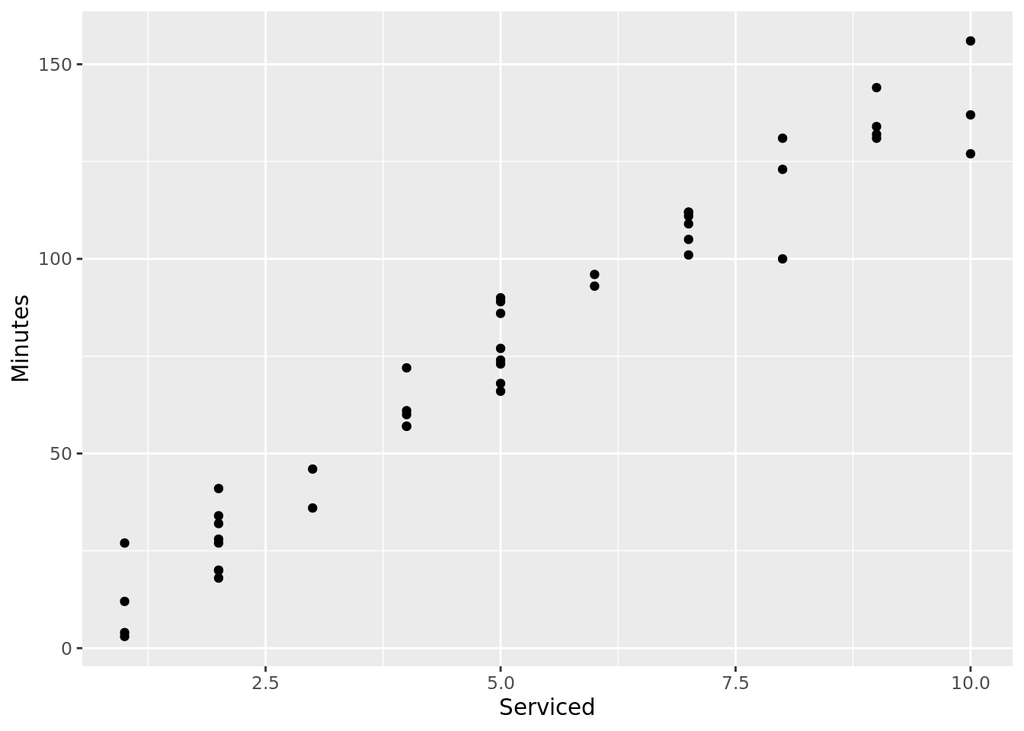

```r
ggplot(copier, aes(x=Serviced, y=Minutes)) +
  geom_point()
```

**(c)** According to the plot, we can find out that there seems to be a high correlation between two variables.

**(d)** When we take a look at the plot, there seems to be a linear relationship between two variables, and according to corrleation, data, there is 0.978517 correlation between two. Therefore, it is reasonable to judge that they are highly correlated.

```r
cor(copier$Serviced, copier$Minutes)
```

```
## [1] 0.978517
```

```r
copier_result <- lm(Minutes ~ Serviced, data = copier)
summary(copier_result)
```

```
##
## Call:
## lm(formula = Minutes ~ Serviced, data = copier)
##
## Residuals:
##      Min       1Q   Median       3Q      Max
## -22.7723  -3.7371   0.3334   6.3334  15.4039
##
## Coefficients:
##             Estimate Std. Error t value Pr(>|t|)
## (Intercept)  -0.5802     2.8039  -0.207    0.837
## Serviced     15.0352     0.4831  31.123   <2e-16 ***
## ---
## Signif. codes:  0 '***' 0.001 '**' 0.01 '*' 0.05 '.' 0.1 ' ' 1
##
## Residual standard error: 8.914 on 43 degrees of freedom
## Multiple R-squared:  0.9575, Adjusted R-squared:  0.9565
## F-statistic: 968.7 on 1 and 43 DF,  p-value: < 2.2e-16
```

**(f)** As $\beta_1 = 15.0352$, every one unit increase of copier machine will lead to an increase of 15.0352 minutes, which is plausible. However, $\beta_0 = -0.5802$ means using 0 copier machine leads to -0.5802 minutes spent, which is impossible in real world settings.

**(g)** $H_0: \beta_1 = 0$, $H_a: \beta_1 \neq 0$

```r
copier_anova <- anova(copier_result)
copier_anova
```

```
## Analysis of Variance Table
##
## Response: Minutes
##           Df Sum Sq Mean Sq F value    Pr(>F)
## Serviced   1  76960   76960  968.66 < 2.2e-16 ***
## Residuals 43   3416      79
## ---
## Signif. codes:  0 '***' 0.001 '**' 0.01 '*' 0.05 '.' 0.1 ' ' 1
```

```r
copier_data <- data.frame(Serviced = 5)

predict(copier_result, copier_data, level = 0.95, interval = "prediction")
```

```
##        fit      lwr      upr
## 1 74.59608 56.42133 92.77084
```

**(i)** Residual, which is equivalent to error between $y_1, \hat{y}_1$ ** is -9.4902.

```r
y_1 <- copier[1,1]
yhat_1 <- 15.0352 * 2 - 0.5802

residual_1 <- y_1 - yhat_1
residual_1
```

```
## [1] -9.4902
```